# Top storm types which effect population health and economic interests

Michael Fierro

January 30, 2016

# Synopsis

In this report, I try to create a simplistic model to determine what types of storms create the most economic damage and pose the biggest threat to population health. The raw data is in the form of a bzip’ed CSV file containing storm information from the US National Oceanic and Atmospheric Administration (NOAA). After analysis, I have found that **tornadoes** pose the greatest risk to population health and also have the greatest economic consequences.

# Required libraries

This report used the following R libraries:

```r
library(plyr)
library(dplyr)
library(ggplot2)
```

# Loading and Processing the Raw Data

The raw data from the NOAA contained more information than was needed for this analysis. There were specific fields that gave the data most relevant to solving the studies questions.

The data is presented in a bzip’d CSV file, which I was able to open and load directly in one step:

```r
weatherData <- read.csv("repdata-data-StormData.csv.bz2", header = TRUE, na.strings = "NA")
```

Due to the size of the data and the large amount of extraneous data, it seemed best to create two dataframes, each based off of weatherData, with the data needed for each analysis. To accomplish this, empty dataframes were created, and then data from weatherData was copied in, as shown below. (** *Note that only the Health data manipulations are shown in this document; Economic data manipulations were exactly the same, just using the corresponding data.* **)

```r
healthWeatherData <- data.frame(EVTYPE=factor(), FATALITIES=numeric(), INJURIES=numeric())
healthWeatherData <- weatherData[,c(8,23,24)]
```

This provided a dataframe named healthWeatherData that contained three fields corresponding to the Event Type, the number of Injuries reported, and the number of Fatalities reported. The best representation of population health incidents was the sum of the number of Fatalities and Injuries. Since this is not available in the NOAA’s data, I used mutate to compute the sum and add it into the dataframe as a new field.

```r
healthComputed <- mutate(healthWeatherData, HealthTotal=FATALITIES+INJURIES)
```

# Results

```r
healthSums <- ddply(healthComputed, .(EVTYPE), summarize, HealthTotal=sum(HealthTotal))
topHealth <- head(healthSums[order(healthSums$HealthTotal, na.last = TRUE, decreasing = TRUE),])
```

The storm type with the greatest impact on population health is the first in the list:

```
##      EVTYPE HealthTotal
## 830 TORNADO       96979
```

The following chart shows that tornadoes easily do the greatest amount of harm to a population’s health.

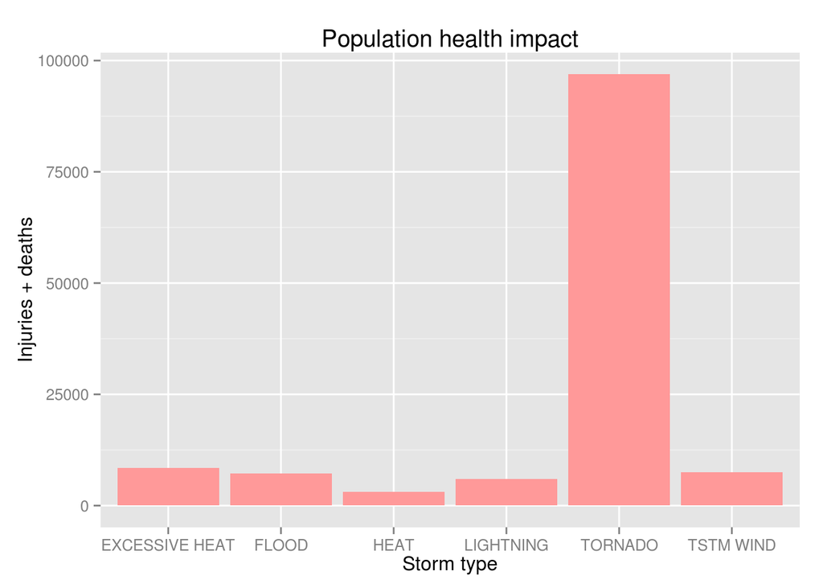

Similarly, tornadoes have the greatest negative economic impact, outpacing all other events (but not as drastically as the impact to health).

```
##      EVTYPE econTotal
## 830 TORNADO   3312277
```

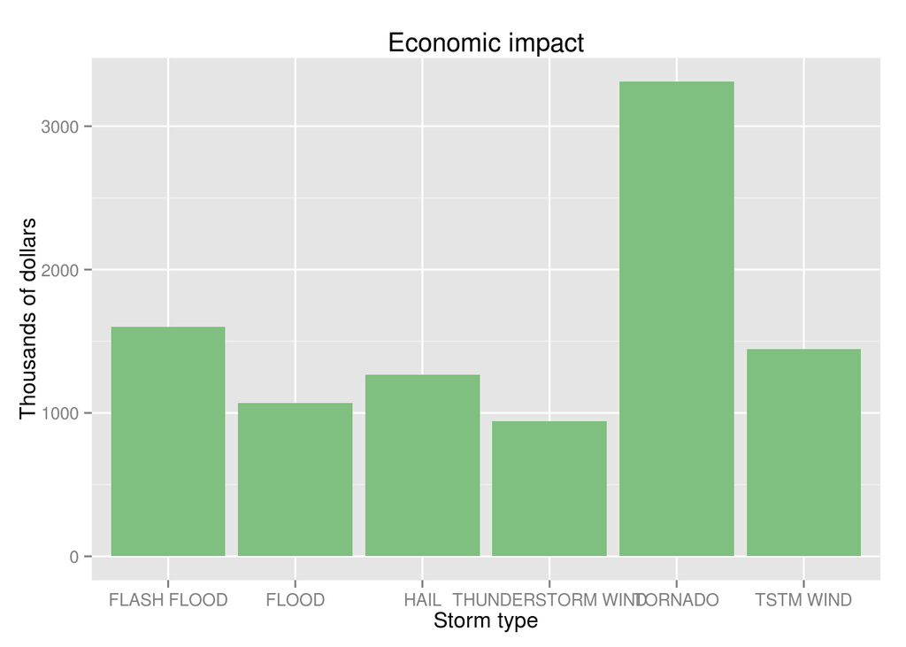